# Aside

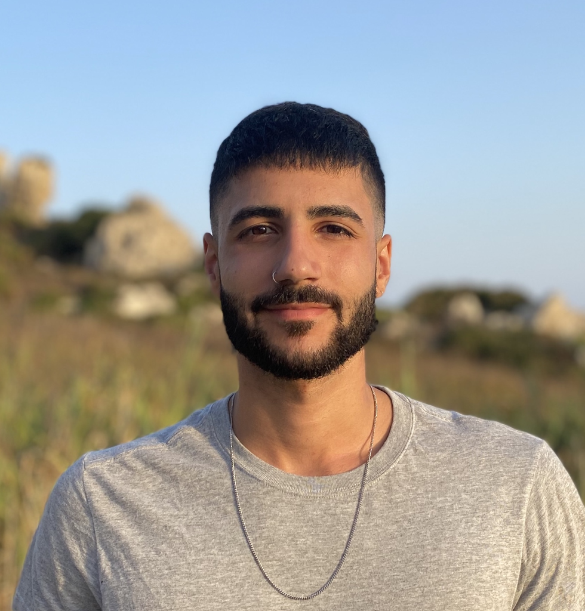

## Contact

- i.e.bostanci@uu.nl
- [LinkedIn](https://www.linkedin.com/in/inan-bostanci/)
- [inan-bostanci.netlify.app](https://inan-bostanci.netlify.app/)

## Software Skills

Python

R

Java

Julia

SPSS

Stata

Mplus

MS Office

## Language Skills

English

German

Turkish

French

Last updated on 2025-06-21.

# Main

## Inan Bostanci

I am a PhD candidate in Mathematics and Computer Science at Freie Universität Berlin, conducting my research at the Zuse Institute Berlin. My work focuses on developing hybrid modeling frameworks that combine agent-based and compartmental (ODE) models to simulate infectious disease spread, integrating real-world mobility, weather, and policy data. I am particularly interested in how individual behavior, mobility, and interventions interact to shape large-scale population health dynamics. My background bridges social science, statistics, and computational modeling, and I enjoy building data-driven models that inform public health forecasting, policy evaluation, and complex systems research.

## Education

### PhD (Dr. rer. nat.) in Mathematics and Computer Science

Free University of Berlin

Germany

2026 - 2022

- Researching hybrid agent-based and ODE models for infectious disease spread, focusing on scalability, realism, and data integration
- Supervised by Dr. Tim Conrad

### MSc Methodology and Statistics in the Behavioral, Biomedical and Social Sciences (graduation in June 22)

Utrecht University

Netherlands

2022 - 2020

- Thesis: Linking traffic loop sensors and administrative data to predict nationwide traffic, supervised by Dr. Peter Lugtig and Yvonne Gotten

### BA Sociology

Leipzig University

Germany

2020 - 2015

- Thesis: The effect of social networks on labour market outcomes, supervised by Dr. Holger Lengfeld

## Employment History

### Researcher

Zuse Institute Berlin

Germany

today - 2022

- Developed a hybrid agent-based and ODE simulation framework, balancing scalability, accuracy, and data fidelity for COVID-19 spread, integrating real-world mobility and weather data
- Applied a deep learning-based neural parameter calibration approach to fit complex ODE models to real-world COVID-19 time series data with custom loss functions and uncertainty quantification techniques
- Led model validation and parameter fitting pipelines to compare simulated vs. empirical case curves
- Contributed to national COVID-19 forecasting via the MODUS-COVID project in collaboration with TU Berlin, delivering simulation-based policy briefs to German health authorities

### Intern Data Science/Methodology in Mobility Research

DaCiMob

Statistics Netherlands (CBS)

2022 - 2021

- Designed and implemented a data linkage framework integrating population registry, traffic sensor data, and geospatial infrastructure to model national rush hour patterns
- Used CBS’s secure big data environment for scalable preprocessing and modeling
- Delivered Jupyter notebooks for traffic prediction and anomaly detection to CBS analysts

### Research Assistant/Intern in T-NAMSE project

Institute for Public Health

Charité - Berlin University of Medicine

2020 - 2019

- Supported national research project on rare disease diagnostics with data management, analysis, and visualization
- Attended internal colloquia on public health research methodology

### Student Assistant

School of Media, Communication and Sociology

University of Leicester

2020 - 2017

- Research project Far-Right Environmental Risk Communication in the European Parliament
- Collecting, monitoring and qualitative coding of data and parliamentary speeches of the EU parliament and of newspaper articles

### Intern Behavioural Policy and Disruptive Technology

Ministry of Trade

Ankara, Republic of Turkey

2019

- Assistance in Turkeys first Nudge Unit (applying behavioural science in public policy)
- Attendance in international meetings to implement blockchain technology in international trade
- Literature reviews

### Student Assistant Chair of Institutions and Social Change

Institute for Sociology

Leipzig University

2019 - 2018

- Data analysis and visualisation, data research, literature research
- Managing the learning management system
- Proof-reading and revising in English and German

### Student Assistant in EU-funded SOLIDUS (Horizon 2020, grant agreement #649489)

Institute for Sociology

Leipzig University

2018 - 2017

- Assisted in authoring of the “European Solidarity in Times of Crisis”-monograph
- Preparing and analysing reports
- Conducting and evaluating focus group meetings, interviews and national seminars

### Teaching Assistant Methods and Statistics

Institute for Sociology

Leipzig University

2017 - 2016

- Tutoring and marking students homework in statistics